# Animal Adoption Rate

Ashley Kim, Gwen Powers, Kevin Cooper

## Overarching Question

How might we promote happiness with pet ownership? What factors impact the adoption of a pet, and likewise, what factors influence an animal not getting adopted?

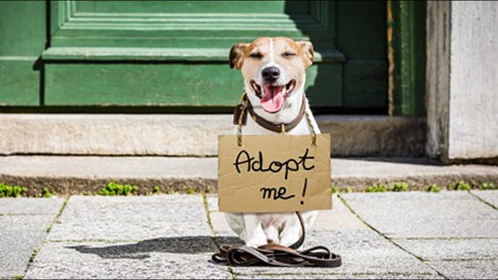

## Background Information

Pets have been proven to affect human happiness and mental health positively. By exploring adoption rates of pets, we hope to find ways to promote happiness with pet ownership and discover what characteristics of an animal (age, color, intake condition, etc.) affect whether it’ll be adopted. We are using animal shelter data from Long Beach, California.

## Cleaning Dataset

```r
shelter_data <- read.csv("C:/Users/kcoop/Desktop/CS/Data Science/3001/DS3001Final/animal-shelter-intakes-and-outcomes.csv")
column_index <- tibble(colnames(shelter_data))
summary(shelter_data)
```

```
##   Animal.ID         Animal.Name        Animal.Type        Primary.Color
##  Length:30617       Length:30617       Length:30617       Length:30617
##  Class :character   Class :character   Class :character   Class :character
##  Mode  :character   Mode  :character   Mode  :character   Mode  :character
##
##
##
##
##  Secondary.Color        Sex                DOB                 Age
##  Length:30617       Length:30617       Length:30617       Min.   :-8.000
##  Class :character   Class :character   Class :character   1st Qu.: 3.000
##  Mode  :character   Mode  :character   Mode  :character   Median : 4.000
##                                                           Mean   : 4.913
##                                                           3rd Qu.: 6.000
##                                                           Max.   :54.000
##                                                           NA's   :3786
##  Intake.Date        Intake.Condition   Intake.Type        Intake.Subtype
##  Length:30617       Length:30617       Length:30617       Length:30617
##  Class :character   Class :character   Class :character   Class :character
##  Mode  :character   Mode  :character   Mode  :character   Mode  :character
##
##
##
##
##  Reason.for.Intake  Outcome.Date         Crossing         Jurisdiction
##  Length:30617       Length:30617       Length:30617       Length:30617
##  Class :character   Class :character   Class :character   Class :character
##  Mode  :character   Mode  :character   Mode  :character   Mode  :character
##
##
##
##
##  Outcome.Type       Outcome.Subtype    intake_is_dead     outcome_is_dead
##  Length:30617       Length:30617       Length:30617       Mode :logical
##  Class :character   Class :character   Class :character   FALSE:24145
##  Mode  :character   Mode  :character   Mode  :character   TRUE :6472
##
##
##
##
##  was_outcome_alive
##  Min.   :0.0000
##  1st Qu.:1.0000
##  Median :1.0000
##  Mean   :0.7886
##  3rd Qu.:1.0000
##  Max.   :1.0000
##
```

[figure not shown]

```
##       Animal.ID Animal.Name Animal.Type Primary.Color Secondary.Color Sex DOB
## 26831         1           1           1             1               1   1   1
## 3786          1           1           1             1               1   1   1
##               0           0           0             0               0   0   0
##       Intake.Date Intake.Condition Intake.Type Intake.Subtype Reason.for.Intake
## 26831           1                1           1              1                 1
## 3786            1                1           1              1                 1
##                 0                0           0              0                 0
##       Outcome.Date Crossing Jurisdiction Outcome.Type Outcome.Subtype
## 26831            1        1            1            1               1
## 3786             1        1            1            1               1
##                  0        0            0            0               0
##       intake_is_dead outcome_is_dead was_outcome_alive  Age
## 26831              1               1                 1    1    0
## 3786               1               1                 1    0    1
##                    0               0                 0 3786 3786
```

```r
mice::md.pattern(shelter_data)
```

```r
shelter_data <- shelter_data[,-c(1,2,5,7,12,13,15,18,19,20,21)]
shelter_data[shelter_data == ""] <- NA
shelter_data<- na.omit(shelter_data)

shelter_data$days_in_shelter <- as.numeric(difftime(shelter_data$Outcome.Date, shelter_data$Intake.Date, units = "days"))

shelter_data <-shelter_data[,-c(5,8)]

# str(shelter_data)

mice::md.pattern(shelter_data)
```

```
##  /\     /\
## {  `---'  }
## {  O   O  }
## ==>  V <==  No need for mice. This data set is completely observed.
##  \  \|/  /
##   `-----'
```

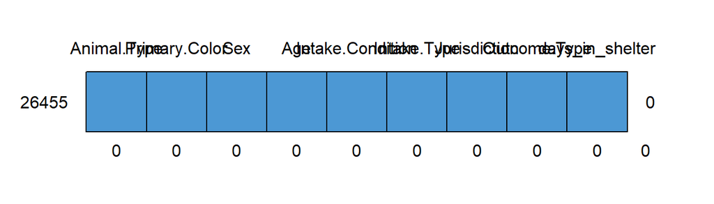

```
##       Animal.Type Primary.Color Sex Age Intake.Condition Intake.Type
## 26455           1             1   1   1                1           1
##                 0             0   0   0                0           0
##       Jurisdiction Outcome.Type days_in_shelter
## 26455            1            1               1 0
##                  0            0               0 0
```

```r
# rescued vs not adopted
# select if shelter outcome is adopted

rescue_data <- subset(shelter_data, (Outcome.Type != "ADOPTION") & (Outcome.Type != "FOSTER TO ADOPT"))

abc <- names(select_if(shelter_data, is.character))
# view(abc)
abc <- abc[-c(4, 7)]
shelter_data[abc] <- lapply(shelter_data[abc], as.factor)
rescue_data[abc] <- lapply(rescue_data[abc], as.factor)
```

### ADOPTED VS NOT ADOPTED

```r
shelter_data$Animal.Type <-
  fct_collapse(shelter_data$Animal.Type,
               Other = c("GUINEA PIG", "LIVESTOCK",
                         "OTHER", "RABBIT", "REPTILE", "WILD"))

shelter_data$Primary.Color <-
  fct_collapse(shelter_data$Primary.Color,
               Orange = c("APRICOT",  "BLONDE", "CR LYNX PT", "CREAM", "CREAM PT",
                          "CRM TABBY", "CRM TIGER","FAWN", "FLAME PT", "GOLD",
                          "ORANGE", "ORG TABBY", "ORG TIGER", "PEACH", "WHEAT",
                          "Y BRINDLE", "YELLOW"),
               Other = c("BL BRINDLE", "BL LYNX PT", "BC LYNX PT",
                         "BLUE","BLUE BRIND", "BLUE CREAM", "BLUE MERLE",
                         "BLUE PT", "BLUE TABBY", "BLUE TICK", "BUFF", "C-T PT",
                         "CALICO", "CALICO DIL", "CALICO PT", "CALICO TAB",
                         "DAPPLE", "GREEN","L-C PT", "LC LYNX PT", "LI LYNX PT",
                         "LILAC PT", "LIVER", "LIVER TICK", "LYNX PT", "PINK",
                         "RD LYNX PT","RED", "RED MERLE", "RUDDY", "S-T PT",
                         "SABLE", "SEAL", "SEAL PT", "ST LYNX PT", "TORBI",
                         "TORTIE", "TORTIE DIL", "TORTIE MUT", "TORTIE PT",
                         "TRICOLOR", "UNKNOWN"),
               Black = c("BLACK","BLK SMOKE", "BLK TABBY", "BLK TIGER"),
               Brown_Tan = c("BR BRINDLE", "BRN MERLE", "BRN TABBY", "BRN TIGER",
                             "BROWN", "CHOC PT","CHOCOLATE", "SEAL", "SEAL PT",
                             "TAN"),
               Gray_White = c("GRAY", "GRAY TABBY", "GRAY TIGER", "WHITE",
                              "SILVER", "SL LYNX PT", "SLVR TABBY", "SNOWSHOE"))

shelter_data$Intake.Condition <-
  fct_collapse(shelter_data$Intake.Condition,
               Other = c("AGED", "UNDER AGE/WEIGHT", "WELFARE SEIZURES"),
               Behavior = c("BEHAVIOR  MILD", "BEHAVIOR  MODERATE",
                            "BEHAVIOR  SEVERE", "FERAL", "FRACTIOUS"),
               Ill_Injured = c("ILL MILD", "ILL MODERATETE", "ILL SEVERE",
                               "INJURED  MILD", "INJURED  MODERATE",
                               "INJURED  SEVERE"),
               Normal = c("NORMAL"))

shelter_data$Intake.Type <-
  fct_collapse(shelter_data$Intake.Type,
               Owner_Surrender = c("OWNER SURRENDER"),
               Stray = c("STRAY"),
               Wildlife = c("WILDLIFE"),
               Other = c("CONFISCATE", "Euthenasia Required", "FOSTER", "RETURN",
                         "SAFE KEEP", "WELFARE SEIZED", "Adopted Animal Return",
                         "QUARANTINE", "TRAP, NEUTER, RETURN"))

shelter_data$Jurisdiction <-
  fct_collapse(shelter_data$Jurisdiction,
               LA = c("LA CITY", "LA COUNTY", "SIGNAL HILL", "TORRANCE AC"),
               OC = c("ORANGE CNTY", "SEAL BEACH", "CERRITOS", "IRVINE",
                      "GARDEN GROVE", "LA HABRA", "LOS ALAMITOS", "SEAACA",
                      "WESTMINSTER"),
               LB= c("LONG BEACH", "DISTRICT1", "DISTRICT2", "DISTRICT3",
                     "DISTRICT4", "DISTRICT5", "DISTRICT6", "DISTRICT7",
                     "DISTRICT8", "DISTRICT9"),
               OOA = c("OUT OF AREA"))

shelter_data$Outcome.Type <-
  fct_collapse(shelter_data$Outcome.Type,
               Adopted = c("ADOPTION", "FOSTER TO ADOPT"),
               Not_Adopted = c("COMMUNITY CAT", "DIED", "DISPOSAL", "DUPLICATE",
                               "EUTHANASIA", "FOSTER", "MISSING",
                               "RETURN TO OWNER", "RETURN TO RESCUE",
                               "RETURN TO WILD HABITAT",
                               "SHELTER, NEUTER, RETURN", "TRANSFER",
                               "TRANSPORT", "TRAP, NEUTER, RELEASE",  "RESCUE"))
```

#### Tabling Each Variable

```r
table(shelter_data$Animal.Type) # bird, cat, dog, other
##
##  BIRD   CAT   DOG Other
##   943 13711  9563  2238
table(shelter_data$Primary.Color) # black, brown/tan, gray/white, orange, other
##
##     Orange      Other      Black  Brown_Tan Gray_White
##       2142       2691       6959       7257       7406
table(shelter_data$Sex) # male, female, neutered, spayed, unknown
##
##   Female     Male Neutered   Spayed  Unknown
##     6438     6910     4677     4215     4215
table(rescue_data$Age) # from -8 to 54
##
##   -8    0    1    2    3    4    5    6    7    8    9   10   11   12   13   14
##    1  828 1638 2226 3182 3721 3161 1616 1322  973  656  544  466  360  319  265
##   15   16   17   18   19   20   21   22   23   24   25   28   54
##  185  151   86   68   39   26   10    8    3    3    1    1    1
table(shelter_data$Intake.Condition) # normal, injured/ill, behavior, other
##
##       Other    Behavior Ill_Injured      Normal
##        5950        1626        4812       14067
table(shelter_data$Intake.Type) # owner surrender, stray, wildlife, other
##
##           Other Owner_Surrender           Stray        Wildlife
##            1350            2729           20124            2252
table(shelter_data$Jurisdiction) # LA, Long Beach, Orange County, Other
##
##    OC    LB    LA   OOA
##  2694 22953   680   128
table(shelter_data$Outcome.Type) # adopted/rescued, not adopted
##
##     Adopted Not_Adopted
##        4595       21860
# table(rescue_data$days_in_shelter) # from 0 to 730
```

### RESCUE VS NOT ADOPTED

```r
rescue_data$Animal.Type <-
  fct_collapse(rescue_data$Animal.Type,
               Other = c("GUINEA PIG", "LIVESTOCK",
                         "OTHER", "RABBIT", "REPTILE", "WILD"))

rescue_data$Primary.Color <-
  fct_collapse(rescue_data$Primary.Color,
               Orange = c("APRICOT",  "BLONDE", "CR LYNX PT", "CREAM", "CREAM PT",
                          "CRM TABBY", "FAWN", "FLAME PT", "GOLD",
                          "ORANGE", "ORG TABBY", "ORG TIGER", "PEACH", "WHEAT",
                          "Y BRINDLE", "YELLOW"),
               Other = c("BL BRINDLE", "BC LYNX PT",
                         "BLUE","BLUE BRIND", "BLUE CREAM", "BLUE MERLE",
                         "BLUE PT", "BLUE TABBY", "BLUE TICK", "BUFF", "C-T PT",
                         "CALICO", "CALICO DIL", "CALICO PT", "CALICO TAB",
                         "DAPPLE", "GREEN","L-C PT", "LC LYNX PT", "LI LYNX PT",
                         "LILAC PT", "LIVER", "LIVER TICK", "LYNX PT", "PINK",
                         "RD LYNX PT","RED", "RED MERLE", "RUDDY", "S-T PT",
                         "SABLE", "SEAL", "SEAL PT", "ST LYNX PT", "TORBI",
                         "TORTIE", "TORTIE DIL", "TORTIE MUT", "TORTIE PT",
                         "TRICOLOR", "UNKNOWN"),
               Black = c("BLACK","BLK SMOKE", "BLK TABBY", "BLK TIGER"),
               Brown_Tan = c("BR BRINDLE", "BRN MERLE", "BRN TABBY", "BRN TIGER",
                             "BROWN", "CHOC PT","CHOCOLATE", "SEAL", "SEAL PT",
                             "TAN"),
               Gray_White = c("GRAY", "GRAY TABBY", "GRAY TIGER", "WHITE",
                              "SILVER", "SL LYNX PT", "SLVR TABBY", "SNOWSHOE"))

rescue_data$Intake.Condition <-
  fct_collapse(rescue_data$Intake.Condition,
               Other = c("AGED", "UNDER AGE/WEIGHT", "WELFARE SEIZURES"),
               Behavior = c("BEHAVIOR  MILD", "BEHAVIOR  MODERATE",
                            "BEHAVIOR  SEVERE", "FERAL", "FRACTIOUS"),
               Ill_Injured = c("ILL MILD", "ILL MODERATETE", "ILL SEVERE",
                               "INJURED  MILD", "INJURED  MODERATE",
                               "INJURED  SEVERE"),
               Normal = c("NORMAL"))

rescue_data$Intake.Type <-
  fct_collapse(rescue_data$Intake.Type,
               Owner_Surrender = c("OWNER SURRENDER"),
               Stray = c("STRAY"),
               Wildlife = c("WILDLIFE"),
               Other = c("CONFISCATE", "Euthenasia Required", "FOSTER", "RETURN",
                         "SAFE KEEP", "WELFARE SEIZED", "Adopted Animal Return",
                         "QUARANTINE", "TRAP, NEUTER, RETURN"))

rescue_data$Jurisdiction <-
  fct_collapse(rescue_data$Jurisdiction,
               LA = c("LA CITY", "LA COUNTY", "SIGNAL HILL"),
               OC = c("ORANGE CNTY", "SEAL BEACH", "CERRITOS", "WESTMINSTER",
                      "GARDEN GROVE", "LA HABRA", "LOS ALAMITOS", "SEAACA"),
               LB= c("LONG BEACH", "DISTRICT1", "DISTRICT2", "DISTRICT3",
                     "DISTRICT4", "DISTRICT5", "DISTRICT6", "DISTRICT7",
                     "DISTRICT8", "DISTRICT9"),
               OOA = c("OUT OF AREA"))

rescue_data$Outcome.Type <-
  fct_collapse(rescue_data$Outcome.Type,
               Rescued = c("RESCUE"),
               Not_Adopted = c("COMMUNITY CAT", "DIED", "DISPOSAL", "DUPLICATE",
                               "EUTHANASIA", "FOSTER", "MISSING",
                               "RETURN TO OWNER", "RETURN TO RESCUE",
                               "RETURN TO WILD HABITAT",
                               "SHELTER, NEUTER, RETURN",
                               "TRANSFER","TRANSPORT", "TRAP, NEUTER, RELEASE"))
```

#### Tabling Each Variable

```r
table(rescue_data$Animal.Type) # bird, cat, dog, other
##
##  BIRD   CAT   DOG Other
##   919 11103  7754  2084
table(rescue_data$Primary.Color) # black, brown/tan, gray/white, orange, other
##
##     Orange      Other      Black  Brown_Tan Gray_White
##       1714       2203       5763       6000       6180
table(rescue_data$Sex) # male, female, neutered, spayed, unknown
##
##   Female     Male Neutered   Spayed  Unknown
##     5925     6432     2805     2512     4186
table(rescue_data$Age) # from -8 to 54
##
##   -8    0    1    2    3    4    5    6    7    8    9   10   11   12   13   14
##    1  828 1638 2226 3182 3721 3161 1616 1322  973  656  544  466  360  319  265
##   15   16   17   18   19   20   21   22   23   24   25   28   54
##  185  151   86   68   39   26   10    8    3    3    1    1    1
table(rescue_data$Intake.Condition) # normal, injured/ill, behavior, other
##
##       Other    Behavior Ill_Injured      Normal
##        5439        1388        4262       10771
table(rescue_data$Intake.Type) # owner surrender, stray, wildlife, other
##
##           Other Owner_Surrender           Stray        Wildlife
##            1089            1952           16570            2249
table(rescue_data$Jurisdiction) # LA, Long Beach, Orange County, Other
##
##    OC    LB    LA   OOA
##  2295 18917   562    86
table(rescue_data$Outcome.Type) # adopted/rescued, not adopted
##
## Not_Adopted     Rescued
##       15729        6131
# table(rescue_data$days_in_shelter) # from 0 to 730
```